# Week 4 Assignment: Hospital Mortality

## Instructions

Download the file ProgAssignment3-data.zip file containing the data for Programming Assignment 3 from the Coursera web site. Unzip the file in a directory that will serve as your working directory. When you start up R make sure to change your working directory to the directory where you unzipped the data.

The data for this assignment come from the [Hospital Compare web site](http://hospitalcompare.hhs.gov) run by the U.S. Department of Health and Human Services. The purpose of the web site is to provide data and information about the quality of care at over 4,000 Medicare-certified hospitals in the U.S. This dataset es- sentially covers all major U.S. hospitals. This dataset is used for a variety of purposes, including determining whether hospitals should be fined for not providing high quality care to patients (see http://goo.gl/jAXFX for some background on this particular topic).

The Hospital Compare web site contains a lot of data and we will only look at a small subset for this assignment.

## Data

The zip file containing the data for this assignment can be downloaded [here](https://d396qusza40orc.cloudfront.net/rprog%2Fdata%2FProgAssignment3-data.zip). The zip file for this assignment contains three files

- `outcome-of-care-measures.csv`: Contains information about 30-day mortality and readmission rates for heart attacks, heart failure, and pneumonia for over 4,000 hospitals.
- `hospital-data.csv`: Contains information about each hospital.
- `Hospital_Revised_Flatfiles.pdf`: Descriptions of the variables in each file (i.e the code book).

A description of the variables in each of the files is in the included PDF file named `Hospital_Revised_Flatfiles.pdf`. This document contains information about many other files that are not included with this programming assignment. You will want to focus on the variables for Number 19 (`Outcome of Care Measures.csv`) and Number 11 (`Hospital Data.csv`). You may find it useful to print out this document (at least the pages for Tables 19 and 11) to have next to you while you work on this assignment. In particular, the numbers of the variables for each table indicate column indices in each table (i.e. `Hospital Name` is column 2 in the `outcome-of-care-measures.csv` file).

```r
download.file(url = 'https://d396qusza40orc.cloudfront.net/rprog%2Fdata%2FProgAssignment3-data.zip',
              destfile = paste0(getwd(), '/hw4_data.zip'),
              method = 'curl', quiet = T)
unzip(zipfile = 'hw4_data.zip')
```

## Part 1: Plot the 30-day mortality rates for heart attack

Read the outcome data into R via the read.csv function and look at the first few rows.

```r
outcome <- read.csv("outcome-of-care-measures.csv", colClasses = "character")
```

There are many columns in this dataset. You can see how many by typing ncol(outcome) (you can see the number of rows with the nrow function). In addition, you can see the names of each column by typing names(outcome) (the names are also in the PDF document.

To make a simple histogram of the 30-day death rates from heart attack (column 11 in the outcome dataset), run

```r
outcome[, 11] <- as.numeric(outcome[, 11])
```

```
## Warning: NAs introduced by coercion
```

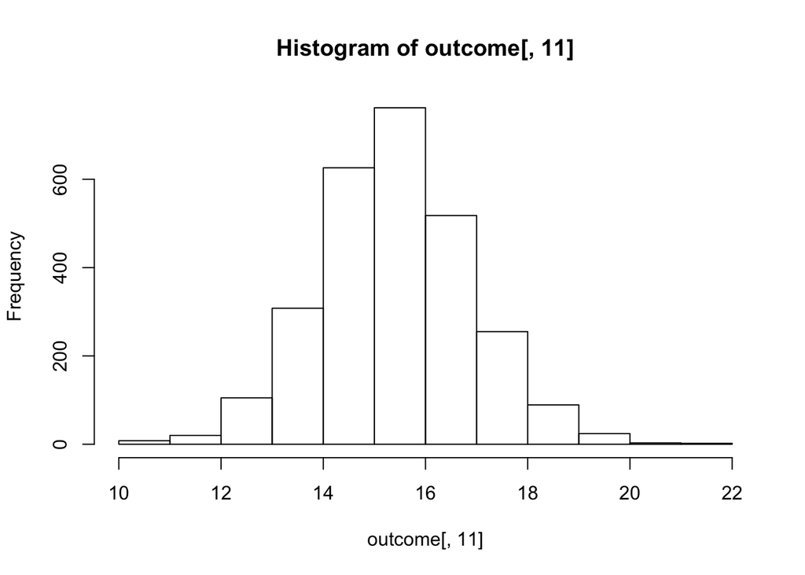

```r
## You may get a warning about NAs being introduced; that is okay
hist(outcome[, 11])
```

Because we originally read the data in as character (by specifying colClasses = “character” we need to coerce the column to be numeric. You may get a warning about NAs being introduced but that is okay.

## Part 2: Finding the best hospital in a state

Write a function called `best` that take two arguments: the 2-character abbreviated name of a state and an outcome name. The function reads the `outcome-of-care-measures.csv` file and returns a character vector with the name of the hospital that has the best (i.e. lowest) 30-day mortality for the specified outcome in that state. The hospital name is the name provided in the `Hospital.Name` variable. The outcomes can be one of “heart attack”, “heart failure”, or “pneumonia”. Hospitals that do not have data on a particular outcome should be excluded from the set of hospitals when deciding the rankings.

**Handling ties**. If there is a tie for the best hospital for a given outcome, then the hospital names should be sorted in alphabetical order and the first hospital in that set should be chosen (i.e. if hospitals “b”, “c”, and “f” are tied for best, then hospital “b” should be returned).

The function should check the validity of its arguments. If an invalid `state` value is passed to `best`, the function should throw an error via the stop function with the exact message “invalid state”. If an invalid `outcome` value is passed to `best`, the function should throw an error via the `stop` function with the exact message “invalid outcome”.

```r
best <- function(state, outcome) {
  #reads the outcome-of-care-measures.csv file and returns a character vector
  #with the name of the hospital that has the best (i.e. lowest) 30-day
  #mortality for the specified outcome in that state. If there is a tie, the
  #hospital names are sorted in alphabetical order and the first hospital in
  #the set would be chosen and returned

  #state: 2-character abbreviated name of the state
  #outcome: one of "heart attack", "heart failure", or "pneumonia"

  ## Read outcome data
  rawData <- read.csv('outcome-of-care-measures.csv', colClasses = 'character')
    #colClasses is important or the columns will be read as functions!!!!
    #b/c there is 'Not available' in the columns
  outcomeData <- rawData[ ,c(2, 7, 11, 17, 23)]
  colnames(outcomeData) <- c('Hospital', 'State', 'heart attack', 'heart failure', 'pneumonia')

  ## Check that state and outcome are valid
  if (state %in% outcomeData[, 2] == FALSE) {
    #if state is not in the state list, stop the function and print error
    stop('invalid state')
  }
  if (outcome %in% colnames(outcomeData)[3:5] == FALSE) {
    #if outcome is not in the outcome list, stop the function and print error
    stop('invalid outcome')
  }

  ## Return hospital name in that state with lowest 30-day death rate
  selectData <- outcomeData[outcomeData$State == state, c('Hospital', 'State', outcome)]
    #select only the query outcome in the state
  selectData <- selectData[order(selectData$Hospital, decreasing = F), ]
    #order hospitals alphabetically
  selectData[, 3] <- suppressWarnings(as.numeric(selectData[, 3]))
    #change the mortality column into numeric
    #warnings for coercing into NA - suppress this warning in the output

  #Return name of the hospital w/ the lowest 30-day death rate
  return(selectData[which.min(selectData[, 3]), 1])
    #which.min only finds the first occurrence
    #in this case since the hospital data is already sorted, the
    #only hospital name returned will be alphabetical
}
```

## Part 3: Ranking hospitals by outcome in a state

Write a function called rankhospital that takes three arguments: the 2-character abbreviated name of a state (`state`), an outcome (`outcome`), and the ranking of a hospital in that state for that outcome (`num`). The function reads the `outcome-of-care-measures.csv` file and returns a character vector with the name of the hospital that has the ranking specified by the `num` argument. For example, the call  
`rankhospital("MD", "heart failure", 5)`  
would return a character vector containing the name of the hospital with the 5th lowest 30-day death rate for heart failure. The `num` argument can take values “best”, “worst”, or an integer indicating the ranking (smaller numbers are better). If the number given by `num` is larger than the number of hospitals in that state, then the function should return `NA`. Hospitals that do not have data on a particular outcome should be excluded from the set of hospitals when deciding the rankings.

**Handling ties**. It may occur that multiple hospitals have the same 30-day mortality rate for a given cause of death. In those cases ties should be broken by using the hospital name. For example, in Texas (“TX”), the hospitals with lowest 30-day mortality rate for heart failure are shown here.

`> head(texas)`  
`Hospital.Name Rate Rank`  
`3935 FORT DUNCAN MEDICAL CENTER 8.1 1`  
`4085 TOMBALL REGIONAL MEDICAL CENTER 8.5 2`  
`4103 CYPRESS FAIRBANKS MEDICAL CENTER 8.7 3`  
`3954 DETAR HOSPITAL NAVARRO 8.7 4`  
`4010 METHODIST HOSPITAL,THE 8.8 5`  
`3962 MISSION REGIONAL MEDICAL CENTER 8.8 6`

Note that Cypress Fairbanks Medical Center and Detar Hospital Navarro both have the same 30-day rate (8.7). However, because Cypress comes before Detar alphabetically, Cypress is ranked number 3 in this scheme and Detar is ranked number 4. One can use the order function to sort multiple vectors in this manner (i.e. where one vector is used to break ties in another vector).

The function should check the validity of its arguments. If an invalid `state` value is passed to `rankhospital`, the function should throw an error via the `stop` function with the exact message “invalid state”. If an invalid `outcome` value is passed to `rankhospital`, the function should throw an error via the `stop` function with the exact message “invalid outcome”.

```r
rankhospital <- function(state, outcome, num = 'best') {
  #reads the outcome-of-care-measures.csv file and returns a character vector with the name
  #of the hospital that has the ranking specified by the num argument

  #state: 2-character abbreviated name of the state
  #outcome: one of "heart attack", "heart failure", or "pneumonia"
  #num: the ranking of a hospital in that state for that outcome can take values "best",
  #"worst", or an integer indicating the ranking (smaller numbers are better)

  #Read outcome data
  rawData <- read.csv('outcome-of-care-measures.csv', colClasses = 'character')
    #colClasses is important or the columns will be read as functions!!!!
    #b/c there is 'Not available' in the columns
  outcomeData <- rawData[ ,c(2, 7, 11, 17, 23)]
  colnames(outcomeData) <- c('Hospital', 'State', 'heart attack', 'heart failure', 'pneumonia')

  #Check that state and outcome are valid
  if (state %in% outcomeData[, 2] == FALSE) {
    #if state is not in the state list, stop the function and print error
    stop('invalid state')
  }
  if (outcome %in% colnames(outcomeData)[3:5] == FALSE) {
    #if outcome is not in the outcome list, stop the function and print error
    stop('invalid outcome')
  }

  #Select data
  selectData <- outcomeData[outcomeData$State == state, c('Hospital', 'State', outcome)]
    #select only the query outcome in the state
  selectData <- selectData[order(selectData$Hospital, decreasing = F), ]
    #order hospitals alphabetically
  selectData[, 3] <- suppressWarnings(as.numeric(selectData[, 3]))
    #change the mortality column into numeric
    #warnings for coercing into NA - suppress this warning in the output
  selectData <- selectData[complete.cases(selectData), ]
    #remove the NAs
  selectData <- selectData[order(selectData[, 3], decreasing = F), ]
    #order the hospitals by smallest mortality on top (rank == 1)
    #this helps breaks the tie


  #Modify the num variable to rank numbers and check numbers
  if (num == 'best') {
    #best finds the top-ranked hospital
    rank <- 1
  } else if (num == 'worst') {
    #worst finds the hospital ranked the last place
    rank <- nrow(selectData)
  } else if (num > nrow(selectData)) {
    #if number larger than the hospitals, function returns NA
    return(NA)
  } else {
    #else, rank == number
    rank <- num
  }

  #Return hospital name in that state with the given rank
  return(selectData[rank, 1])
  #first column is the hospital name
  #row number is the rank
}
```

## Part 4: Ranking hospitals in all states

Write a function called rankall that takes two arguments: an outcome name (`outcome`) and a hospital ranking (`num`). The function reads the `outcome-of-care-measures.csv` file and returns a 2-column data frame containing the hospital in each state that has the ranking specified in `num`. For example the function call `rankall("heart attack", "best")` would return a data frame containing the names of the hospitals that are the best in their respective states for 30-day heart attack death rates. The function should return a value for every state (some may be `NA`). The first column in the data frame is named `hospital`, which contains the hospital name, and the second column is named `state`, which contains the 2-character abbreviation for the state name. Hospitals that do not have data on a particular outcome should be excluded from the set of hospitals when deciding the rankings.

**Handling ties**. The `rankall` function should handle ties in the 30-day mortality rates in the same way that the `rankhospital` function handles ties.

**NOTE**: For the purpose of this part of the assignment (and for efficiency), your function should NOT call the `rankhospital` function from the previous section.

The function should check the validity of its arguments. If an invalid `outcome` value is passed to `rankall`, the function should throw an error via the `stop` function with the exact message “invalid outcome”. The `num` variable can take values “best”, “worst”, or an integer indicating the ranking (smaller numbers are better). If the number given by `num` is larger than the number of hospitals in that state, then the function should return `NA`.

```r
rankall <- function(outcome, num = 'best') {
  #reads the outcome-of-care-measures.csv file and returns a 2-column data frame
  #containing the hospital in each state that has the ranking specified in num.
  #the first column in the data frame is named hospital, which contains the
  #hospital name, and the second column is named state, which contains the
  #2-character abbreviation for the state name.


  ## Read outcome data
  rawData <- read.csv('outcome-of-care-measures.csv', colClasses = 'character')
  #colClasses is important or the columns will be read as functions!!!!
  #b/c there is 'Not available' in the columns
  outcomeData <- rawData[ ,c(2, 7, 11, 17, 23)]
  colnames(outcomeData) <- c('Hospital', 'State', 'heart attack', 'heart failure', 'pneumonia')

  ## Check that state and outcome are valid
  if (outcome %in% colnames(outcomeData)[3:5] == FALSE) {
    #if outcome is not in the outcome list, stop the function and print error
    stop('invalid outcome')
  }

  ## Select data
  selectData <- outcomeData[, c('Hospital', 'State', outcome)]
  selectData[, 3] <- suppressWarnings(as.numeric(selectData[, 3]))
  #change the mortality column into numeric
  #warnings for coercing into NA - suppress this warning in the output
  selectData <- selectData[complete.cases(selectData), ]
  #remove the NAs
  selectData <- selectData[order(selectData$Hospital, decreasing = F), ]
  #order hospitals alphabetically
  if (num == 'best') {
    #order the hospitals by smallest mortality on top (rank == 1)
    selectData <- selectData[order(selectData[, 3], decreasing = F), ]
    rank <- 1
  } else if (num == 'worst') {
    #sort the dataframe by increasing so the first row would be the worst hospital
    selectData <- selectData[order(selectData[, 3], decreasing = T), ]
    rank <- 1
  } else {
        selectData <- selectData[order(selectData[, 3], decreasing = F), ]
        rank <- num
  }

  ## For each state, find the hospital of the given rank
  splitData <- split(selectData[, c(1, 3)], selectData$State)
  #split the hospital data by state and retain the hospital name (col 1) and the
  #mortality rate (col 2)
  hospital <- sapply(splitData, function(x) x[rank, 1])
  #now splitData either is ascending or descending depending on best/worst
  #regardless, the rank is all the same
  #use sapply and apply the function that returns a data frame of row == rank,
  #and hospital name (col 1)

  hospital <- data.frame(hospital)
  #make the result a dataframe
  hospital$state <- row.names(hospital)
  #add a second column that is the state (also the row names of the hospital df)

  return(hospital)
}
```

## Quiz

1. What result is returned by the following code?

```r
best("SC", "heart attack")
```

```
## [1] "MUSC MEDICAL CENTER"
```

2. What result is returned by the following code?

```r
best("NY", "pneumonia")
```

```
## [1] "MAIMONIDES MEDICAL CENTER"
```

3. What result is returned by the following code?

```r
best("AK", "pneumonia")
```

```
## [1] "YUKON KUSKOKWIM DELTA REG HOSPITAL"
```

4. What result is returned by the following code?

```r
rankhospital("NC", "heart attack", "worst")
```

```
## [1] "WAYNE MEMORIAL HOSPITAL"
```

5. What result is returned by the following code?

```r
rankhospital("WA", "heart attack", 7)
```

```
## [1] "YAKIMA VALLEY MEMORIAL HOSPITAL"
```

6. What result is returned by the following code?

```r
rankhospital("TX", "pneumonia", 10)
```

```
## [1] "SETON SMITHVILLE REGIONAL HOSPITAL"
```

7. What result is returned by the following code?

```r
rankhospital("NY", "heart attack", 7)
```

```
## [1] "BELLEVUE HOSPITAL CENTER"
```

8. What result is returned by the following code?

```r
r <- rankall("heart attack", 4)
as.character(subset(r, state == "HI")$hospital)
```

```
## [1] "CASTLE MEDICAL CENTER"
```

9. What result is returned by the following code?

```r
r <- rankall("pneumonia", "worst")
as.character(subset(r, state == "NJ")$hospital)
```

```
## [1] "BERGEN REGIONAL MEDICAL CENTER"
```

10. What result is returned by the following code?

```r
r <- rankall("heart failure", 10)
as.character(subset(r, state == "NV")$hospital)
```

```
## [1] "RENOWN SOUTH MEADOWS MEDICAL CENTER"
```